# L: Designing Projects using Text Analysis

Bogdan G. Popescu

bogdan.popescu@johncabot.edu

Tecnológico de Monterrey

## Agenda

Tips for Final Project

- how to find a topic
- should you start with data or with question?
- where to find data

Essentials of Scraping Websites

Ideas for Projects

## Intro

The final project is your chance to *shine* — to apply everything you’ve learned in this course and explore a text-based research question that excites you.

This is your opportunity to move from learning methods to actually *doing research* with them.

- Use at least one Text-as-Data method studied in this course
- Formulate and answer a clear research question
- Demonstrate your ability to use and interpret the method

## Criteria for Grading

- Clear and Answerable question
- Description of the selected method
- Description of the Dataset used in the analysis
- Implementation of the chosen method
- Accurate interpretation of the method output
- Attempts to validate the approach
- Code Quality
- Additional points for originality and ambition

## How to Find a Question

Read papers that use text analysis  
Think about what excites you in text analysis  
You can start with a question or a dataset

## What Should Come First?

### Questions or Data? Which one comes first?

Both approaches are valid — here’s a quick comparison:

**Start with a Question**

**Advantages**

- Likely to lead to more interesting questions
- Less time dedicated to exploring different methods
- The question will guide the analysis

**Disadvantages**

- Likely a lot of time spent collecting data
- Data may not exist in an easily accessible format
- You will need to spend time collecting data.

## What Should Come First?

### Questions or Data? Which one comes first?

Both approaches are valid — here’s a quick comparison:

**Start with Data**

**Advantages**

- You will realize soon if there are any findings worth discussing
- You won’t spend extensive amounts of time trying to find data

**Disadvantages**

- The research questions may be less interesting

## How to Design a Strong Project

1. **Explain what is the concept that you are trying to measure.**
- are you measuring agressions, hatred, use of scientific facts?
- is the way you measure the concept new?
2. **Validate your measure**
- handcode a few documents to show that the quantitative text measure is similar to the way a human would code the text
- show some validity checks: does the measure correlate with events in a way that makes sense?
3. **Use your measure to show variation (over time, by geography, etc.)**

## How to Find a Research Questions

You can pick up on research ideas from academic articles.

- you can pick up technique especially if you examine the replication files
- however, your questions may not be the most original

**Journals**

- American Journal of Political Science
- American Political Science Review
- Journal of Politics
- British Journal of Political Science

**Magazines**

- The Economist
- The Financial Times
- Podcasts

## Existing Datasets

### Example: Harvard Dataverse

The [Harvard Dataverse](https://dataverse.harvard.edu) is a data and code repository for many social science journals.

This is an excellent source of data for your projects!

It will sometimes take some time to find files in the different repositories.

## Existing Datasets

### Example: Harvard Dataverse

[figure not shown]

## Existing Datasets

### Example: Harvard Dataverse

[figure not shown]

## Existing Datasets

### Example: Harvard Dataverse

[figure not shown]

## Existing Datasets

### Example: Harvard Dataverse

[figure not shown]

## Existing Datasets

### Example: Harvard Dataverse

[figure not shown]

## Existing Datasets

### Example: Harvard Dataverse Scroll Down

[figure not shown]

## Existing Datasets

### Example: Harvard Dataverse

[figure not shown]

## Existing Datasets

### Example: Harvard Dataverse

[figure not shown]

## Existing Datasets

### Example: Harvard Dataverse

[figure not shown]

## Existing Datasets

### Example: Harvard Dataverse

[figure not shown]

## Existing Datasets

### Example: Harvard Dataverse

[figure not shown]

## Existing Datasets

### Example: Harvard Dataverse

[figure not shown]

## Existing Datasets

### Example: Harvard Dataverse

[figure not shown]

## Existing Datasets

### Example: Harvard Dataverse

Even better you can download the entire dataset and read the “Read Me” file.

[figure not shown]

## Existing Datasets

### Example: Harvard Dataverse

Even better you can download the entire dataset and read the “Read Me” file.

[figure not shown]

## Existing Datasets

### Example: Kaggle Dataverse

[figure not shown]

## Existing Datasets

### Example: Kaggle Dataverse

[figure not shown]

## Existing Datasets

### Example: Kaggle Dataverse

[Kaggle](https://www.kaggle.com/) is a platform with a wide variety of text datasets.

Some examples of dataset which could be useful to people studying social sciences include.

- [arXiv Scientific Research Papers Dataset](https://www.kaggle.com/datasets/sumitm004/arxiv-scientific-research-papers-dataset)
- [Fake and Real News Dataset](https://www.kaggle.com/datasets/clmentbisaillon/fake-and-real-news-dataset)
- [Political Bias](https://www.kaggle.com/datasets/mayobanexsantana/political-bias)
- [TikTok Refugee Migration Data](https://www.kaggle.com/datasets/jinghuawu/tiktok-refugee-migration-data)

Be careful: still make sure to identify the source of the data and all other relevant information

## Scraping Data

Newspaper3k is a and Article scraping & curation library

## Scraping Data

This is how we can use it:

```python
#pip install lxml_html_clean
from newspaper import Article
# URL of the article you want to scrape
url = "https://www.bbc.com/news/articles/cr52yrgq48no"

# Create an Article object with the given URL and language (e.g., 'en' for English)
toi_article = Article(url, language="en")

# To download the article
toi_article.download()

# To parse the article (i.e., extract the content)
toi_article.parse()
```

## Scraping Data

This is the result:

```python
# To extract the article's full text
print(toi_article.text)
```

```
Five takeaways from leaked US top military chat group

25 March 2025 Share Save Paulin Kola BBC News Share Save

Watch: Key reactions to reports of a leaked group chat involving Trump officials

Washington DC is still digesting a serious security breach at the heart of the Trump administration. It's the story of how a journalist - the Atlantic magazine's Jeffrey Goldberg - was added to a Signal platform messaging group which apparently included Vice-President JD Vance and Defence Secretary …

EPA Trump and his top aides have consistently raised concerns about footing the bill for European defence

Vance questions Trump's thinking

On the military action, Goldberg reported that the account named JD Vance wrote: "I think we are making a mistake." The vice-president said targeting Houthi forces that are attacking vessels in the Suez Canal serves European interests more than the US, because Europe has more trade running through t…

Blame for 'free-loading' Europe

Arguments over why the US could - and should - carry out the military strike against the Houthis did not sway Vance. He said to the defence secretary, "If you think we should do it let's go. I just hate bailing Europe out again." Hegseth reciprocated: "I fully share your loathing of European free-lo…

After the strike: Emojis and prayers

According to Goldberg, the US national security chief posted three emojis after the strike: "a fist, an American flag, and fire". The Middle East special envoy, Steve Witkoff, responded with five emojis, Goldberg said: "two hands-praying, a flexed bicep, and two American flags". Secretary of State M…

Controlling the message: Blame Biden

To Vance's concerns that the action may be seen as going against Trump's message on Europe, the US defence secretary wrote: "VP: I understand your concerns – and fully support you raising w/ POTUS [Trump]. Important considerations, most of which are tough to know how they play out (economy, Ukraine …

Watch: President Trump says he knows 'nothing' about journalist in Houthi strike group chat

Waltz in the spotlight
```

## Scraping Data

If you want to scrape multiple articles, you would do something like this

```python
url1 = "https://www.bbc.com/news/articles/cr52yrgq48no"
url2 = "https://www.bbc.com/news/articles/cvgwjllld1ro"
url2 = "https://www.bbc.com/news/articles/c93n05z48ldo"
```

## Scraping Data

We would do something like this:

```python
import pandas as pd
# List of article URLs
urls = [
    "https://www.bbc.com/news/articles/cr52yrgq48no",
    "https://www.bbc.com/news/articles/cvgwjllld1ro",
    "https://www.bbc.com/news/articles/c93n05z48ldo"]

# List to hold article dictionaries
articles_data = []

# Loop through the URLs and process each article
for url in urls:
    article = Article(url, language="en")
    article.download()
    article.parse()
    article.nlp()  # Optional, provides .summary and .keywords

    article_dict = {
        "url": url,
        "title": article.title,
        "summary": article.summary,
        "keywords": article.keywords,
        "text": article.text,
        "date": article.publish_date
    }
    articles_data.append(article_dict)

articles_df = pd.DataFrame(articles_data)
```

## Scraping Data

| url | title | summary | keywords | text | date |
| --- | --- | --- | --- | --- | --- |
| https://www.bbc.com/news/articles/cr52yrgq48no | Signal war plans chat: Five takeaways from leaked US top military meeting | Goldberg said he had seen classified military plans for the strikes, including weapons packages, targets and timing, two hours before the bombs struck.\nBlame for 'free-loading' EuropeArguments over w… | [leaked, emojis, vance, plans, signal, group, goldberg, strike, meeting, european, war, europe, secretary, chat, takeaways, military, trump] | Five takeaways from leaked US top military chat group\n\n25 March 2025 Share Save Paulin Kola BBC News Share Save\n\nWatch: Key reactions to reports of a leaked group chat involving Trump officials\n\… | None |

## Applications of Quantitative Text Analysis

1. **When did Western Political Thought start diverging from Islamic political thought?**

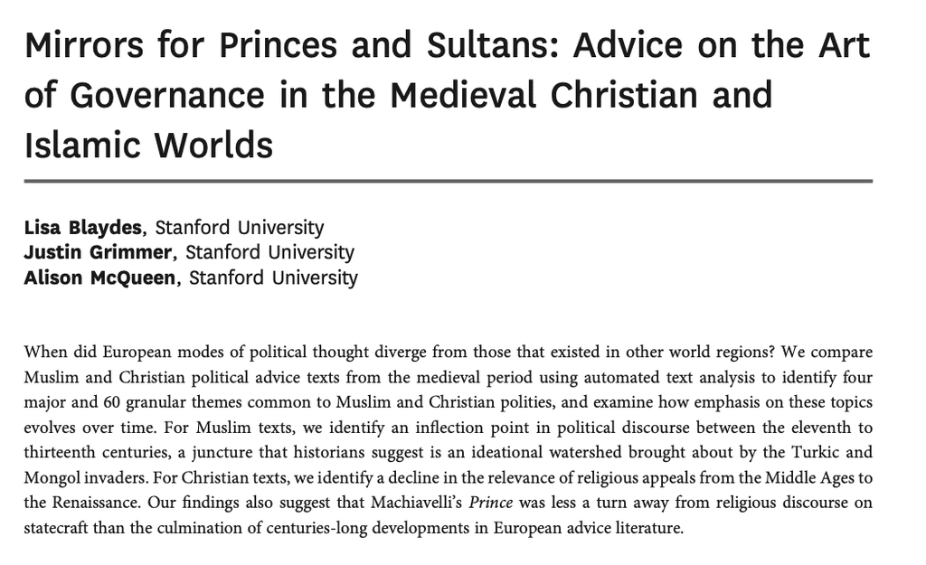

## Applications of Quantitative Text Analysis

1. **When did Western Political Thought start diverging from Islamic political thought?**

https://doi.org/10.7910/DVN/CV9AYE

- The replication files contain all the 46 books, already split in 9,838 sections
- These are Islamic and Christian books
- The authors identify how topics in these two traditions from 600 to 1600

## Applications of Quantitative Text Analysis

1. **When did Western Political Thought start diverging from Islamic political thought?**

Some interesting project ideas based on the same article:

- How do different eras describe the qualities of a good military leader?
- How is the metaphor of family or marriage used to talk about ruling?
- What behaviors are praised or condemned in different political systems?

## Applications of Quantitative Text Analysis

2. **Do men and women debate differently?**

[figure not shown]

## Applications of Quantitative Text Analysis

2. **Do men and women debate differently?**

https://doi.org/10.7910/DVN/PPSFLT

## Applications of Quantitative Text Analysis

2. **Do men and women debate differently?**

Some interesting project ideas based on the same article:

- Do Labour and Conservative MPs exhibit different stylistic trends over time, and how do those intersect with gender?
- Does being in a leadership role (e.g. frontbench, committee chair) affect the stylistic choices of MPs? Is this effect gendered?
- Are some styles more prominent in debates on certain topics (e.g., defense, health, education)? Does gender affect this?

## Applications of Quantitative Text Analysis

3. **How does bureaucratic reputation vary over time in the UK and the US?**

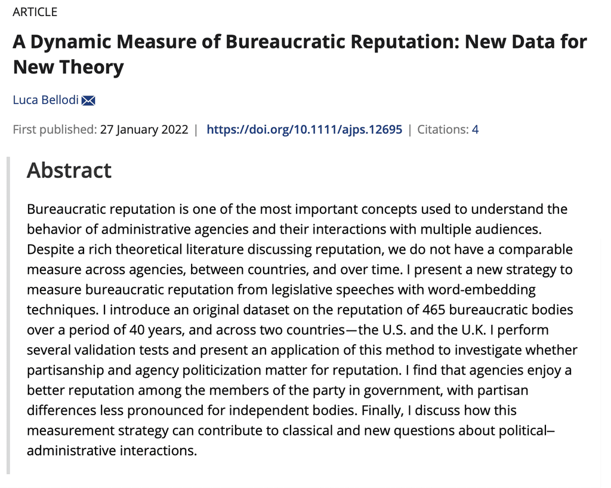

## Applications of Quantitative Text Analysis

3. **How does bureaucratic reputation vary over time in the UK and the US?**

https://doi.org/10.7910/DVN/KL36TP

- The replication files contain 2,528,833 politician speeches in the US and 2,370,131 in the UK
- They span over a period of 40 years

## Applications of Quantitative Text Analysis

3. **How does bureaucratic reputation vary over time in the UK and the US?**

Some interesting project ideas based on the same article:

- Do independent agencies enjoy more stable or higher reputation than executive departments?
- Do similar types of agencies (e.g., central banks) have similar reputations across countries? Compare the Fed and Bank of England.
- Do agencies with greater formal independence (or insulation from politics) have more stable or polarized reputations?

## Applications of Quantitative Text Analysis

4. **How do incumbents eligible for reelection focus on policies that have high yield in Mexico**

[figure not shown]

## Applications of Quantitative Text Analysis

4. **How do incumbents eligible for reelection focus on policies that have high yield in Mexico**

https://doi.org/10.7910/DVN/NOMC0H

## Applications of Quantitative Text Analysis

4. **How do incumbents eligible for reelection focus on policies that have high yield in Mexico**

Some interesting project ideas based on the same article:

- Do male and female legislators differ in their attention to particularistic legislation?
- Does the day of the week or proximity to an election affect legislative focus on particularistic topics?
- Are legislators more likely to focus on physical infrastructure (roads, bridges) or social programs (scholarships, aid) when facing reelection?

## Ready to Get Started?

Think about:

- What social or political issue fascinates you?
- What dataset might help you explore it?
- What method would give you insight?

Let’s build something cool.

- Come and discuss your ideas with me next week (week 11)